# Transportation Network Companies (TNCs) Effect on Rail Ridership

2024-01-23

## Background and Literature

- Declining Public Transportation Usage
- TNC’s Impact on Public Transportation
  - Reduces public transit demand in cities with “high urban compactness” (Lee, et. al 2019)
  - Serves as compliment (net) but masks heterogeneity (Hall, et. al 2018)
  - Serves as compliment to high quality public transit but substitute to low quality transit (Zhao 2019)

## Research Question and Methodology

- Can Uber be used to supplement public transportation by offering a solution to the FM/LM problem?
  - Diff-in-diff comparing Buffalo and similar cities
  - Spatial analysis of customers added with introduction of Uber (?)

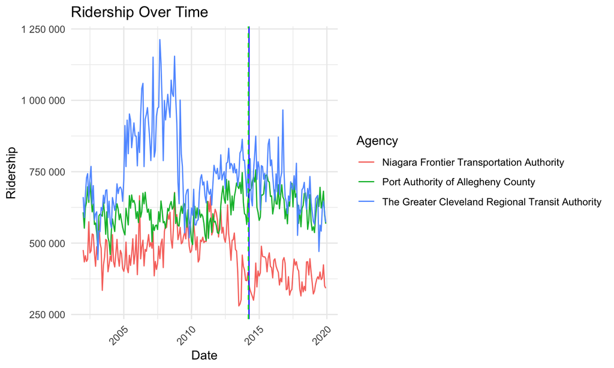

## Data Sources

- National Transit Database (NTD)
  - Contains monthly ridership data from 2002-present for all public transportation agencies that receive federal funding
- Google search data

| agency | date | ridership | month | year | uber_legal | post_2014 | treated |
| --- | --- | --- | --- | --- | --- | --- | --- |
| Niagara Frontier Transportation Authority | 2002-01-01 | 475848 | jan | 2002 | 0 | 0 | 0 |
| Niagara Frontier Transportation Authority | 2002-02-01 | 434141 | feb | 2002 | 0 | 0 | 0 |
| Niagara Frontier Transportation Authority | 2002-03-01 | 455848 | mar | 2002 | 0 | 0 | 0 |
| The Greater Cleveland Regional Transit Authority | 2019-10-01 | 646707 | oct | 2019 | 1 | 1 | 1 |
| The Greater Cleveland Regional Transit Authority | 2019-11-01 | 605660 | nov | 2019 | 1 | 1 | 1 |
| The Greater Cleveland Regional Transit Authority | 2019-12-01 | 572804 | dec | 2019 | 1 | 1 | 1 |

## References

Hall, J. D., Palsson, C., and Price, J. (2018). Is uber a substitute or complement for public transit? Journal of Urban Economics, 108:36–50.

Lee, Kyunghee and Jin, Qianran and Animesh, Animesh and Ramaprasad, Jui, Impact of Ride-Hailing Services on Transportation Mode Choices: Evidence from Traffic and Transit Ridership (October 31, 2019). Forthcoming at MIS Quarterly, Available at SSRN: https://ssrn.com/abstract=3244207 or http://dx.doi.org/10.2139/ssrn.3244207

Zhao, W. (2019). The Long Run Effects of Uber on Public Transit, Congestion, Sprawl, and the Environment.